# The Grammar of Seeing — Workshop

Companion code for the data visualization lecture

R for Clinicians · Lecture 07

יוני 2026

# Before we start

This file is the workshop companion to the lecture deck. The deck makes the argument; this file builds the charts. We use the same dataset throughout — `PimaIndiansDiabetes` — so the only thing changing from chunk to chunk is the visualization choice.

> **The rule of this workshop:** every chunk should change exactly one thing. Watch what happens.

> Homework is in a separate file (`visualization_homework.Rmd`).

## Packages

```r
library(tidyverse)   # ggplot2, dplyr, forcats, tibble
library(mlbench)     # PimaIndiansDiabetes dataset
library(scales)      # nicer axis formatting
```

If any of these are missing:

```r
install.packages(c("tidyverse", "mlbench", "scales"))
```

## The data

```r
data("PimaIndiansDiabetes")
pima <- as_tibble(PimaIndiansDiabetes)

pima
```

| pregnant | glucose | pressure | triceps | insulin | mass | pedigree | age | diabetes |
| --- | --- | --- | --- | --- | --- | --- | --- | --- |
| 6 | 148 | 72 | 35 | 0 | 33.6 | 0.627 | 50 | pos |
| 1 | 85 | 66 | 29 | 0 | 26.6 | 0.351 | 31 | neg |
| 8 | 183 | 64 | 0 | 0 | 23.3 | 0.672 | 32 | pos |
| 1 | 89 | 66 | 23 | 94 | 28.1 | 0.167 | 21 | neg |
| 0 | 137 | 40 | 35 | 168 | 43.1 | 2.288 | 33 | pos |
| 5 | 116 | 74 | 0 | 0 | 25.6 | 0.201 | 30 | neg |
| 3 | 78 | 50 | 32 | 88 | 31.0 | 0.248 | 26 | pos |
| 10 | 115 | 0 | 0 | 0 | 35.3 | 0.134 | 29 | neg |
| 2 | 197 | 70 | 45 | 543 | 30.5 | 0.158 | 53 | pos |
| 8 | 125 | 96 | 0 | 0 | 0.0 | 0.232 | 54 | pos |

[output cut: 758 more lines]

A quick orientation:

```r
glimpse(pima)
```

```
## Rows: 768
## Columns: 9
## $ pregnant <dbl> 6, 1, 8, 1, 0, 5, 3, 10, 2, 8, 4, 10, 10, 1, 5, 7, 0, 7, 1, 1…
## $ glucose  <dbl> 148, 85, 183, 89, 137, 116, 78, 115, 197, 125, 110, 168, 139,…
## $ pressure <dbl> 72, 66, 64, 66, 40, 74, 50, 0, 70, 96, 92, 74, 80, 60, 72, 0,…
## $ triceps  <dbl> 35, 29, 0, 23, 35, 0, 32, 0, 45, 0, 0, 0, 0, 23, 19, 0, 47, 0…
## $ insulin  <dbl> 0, 0, 0, 94, 168, 0, 88, 0, 543, 0, 0, 0, 0, 846, 175, 0, 230…
## $ mass     <dbl> 33.6, 26.6, 23.3, 28.1, 43.1, 25.6, 31.0, 35.3, 30.5, 0.0, 37…
## $ pedigree <dbl> 0.627, 0.351, 0.672, 0.167, 2.288, 0.201, 0.248, 0.134, 0.158…
## $ age      <dbl> 50, 31, 32, 21, 33, 30, 26, 29, 53, 54, 30, 34, 57, 59, 51, 3…
## $ diabetes <fct> pos, neg, pos, neg, pos, neg, pos, neg, pos, pos, neg, pos, n…
```

768 patients, 8 numeric variables, 1 categorical outcome (`diabetes`). This is enough variety to demonstrate every chart type we care about.

# Part I — Why we visualize

## Anscombe’s Quartet — same statistics, different stories

Before we touch `pima`, a quick demonstration of why summary statistics aren’t enough. R ships with Anscombe’s Quartet built in.

```r
anscombe_long <- anscombe |>
  pivot_longer(everything(),
               names_to  = c(".value", "set"),
               names_pattern = "(.)(.)")

# Verify all four datasets have nearly identical statistics
anscombe_long |>
  group_by(set) |>
  summarise(
    mean_x = mean(x),
    mean_y = round(mean(y), 2),
    sd_x   = sd(x),
    sd_y   = round(sd(y), 2),
    cor    = round(cor(x, y), 3)
  )
```

| set | mean_x | mean_y | sd_x | sd_y | cor |
| --- | --- | --- | --- | --- | --- |
| 1 | 9 | 7.5 | 3.316625 | 2.03 | 0.816 |
| 2 | 9 | 7.5 | 3.316625 | 2.03 | 0.816 |
| 3 | 9 | 7.5 | 3.316625 | 2.03 | 0.816 |
| 4 | 9 | 7.5 | 3.316625 | 2.03 | 0.817 |

Now plot them:

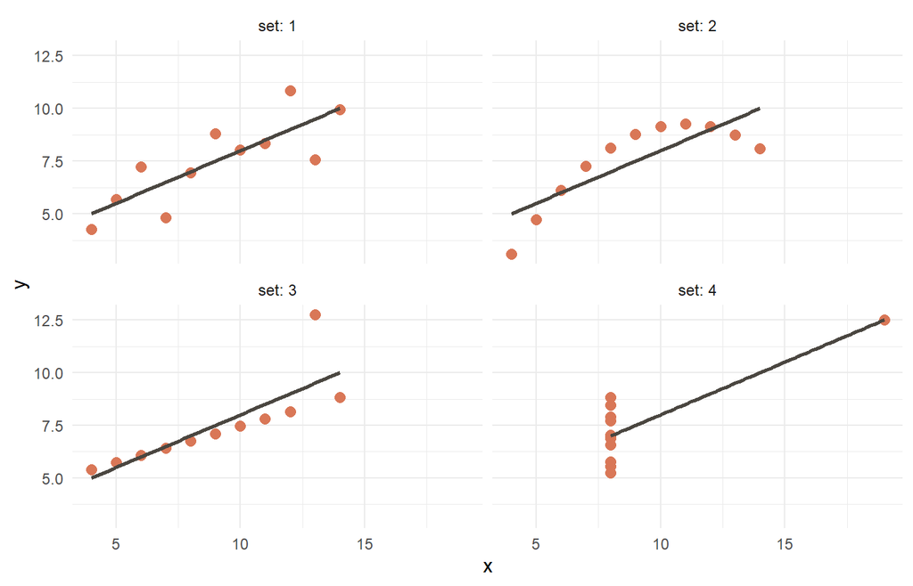

```r
ggplot(anscombe_long, aes(x, y)) +
  geom_point(size = 2.5, color = "#d97757") +
  geom_smooth(method = "lm", se = FALSE, color = "#4a4640") +
  facet_wrap(~ set, labeller = label_both) +
  theme_minimal()
```

**Identical mean, sd, correlation, regression line. Four completely different worlds.** This is why we don’t trust the table alone.

# Part II — Building in ggplot2

## The grammar in one chart

Every ggplot is built in layers:

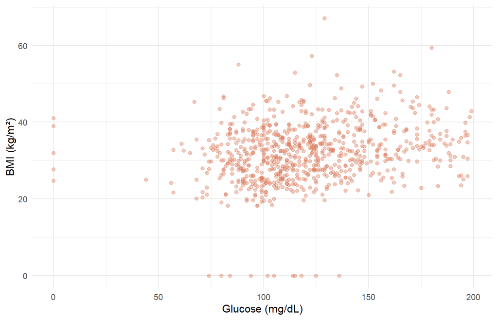

```r
ggplot(data = pima) +                            # 1. data
  aes(x = glucose, y = mass) +                   # 2. aesthetics
  geom_point(alpha = 0.4, color = "#d97757") +   # 3. geometry
  theme_minimal() +                              # 4. refinement
  labs(x = "Glucose (mg/dL)", y = "BMI (kg/m²)")
```

## Why continuous goes to position, categorical goes to colour

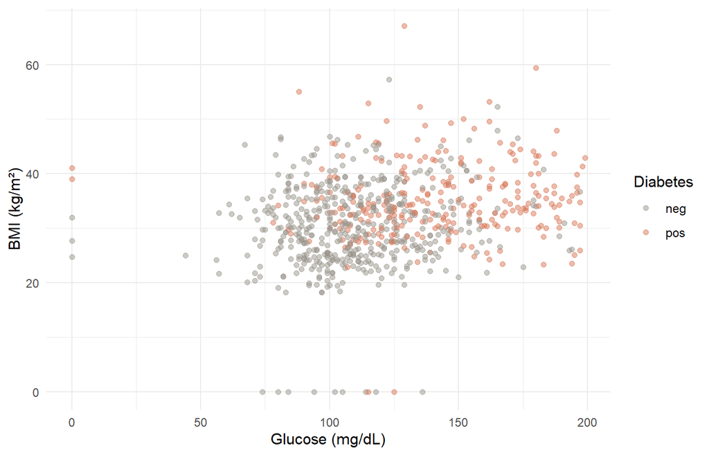

```r
ggplot(pima, aes(x = glucose, y = mass, color = diabetes)) +
  geom_point(alpha = 0.5) +
  scale_color_manual(values = c("neg" = "#9a958c", "pos" = "#d97757")) +
  theme_minimal() +
  labs(
    x = "Glucose (mg/dL)",
    y = "BMI (kg/m²)",
    color = "Diabetes"
  )
```

Position carries the two continuous measurements (the precise channels). Colour carries the categorical group (the weaker channel, but enough to distinguish two classes).

# Part III — The three winning charts

## 1. Bar chart — comparing categories

We need a categorical variable to count. The Pima dataset only has `diabetes`, so let’s build a more interesting one by binning age:

```r
pima_age <- pima |>
  mutate(
    age_group = cut(age,
                    breaks = c(20, 30, 40, 50, 60, 90),
                    labels = c("21–30", "31–40", "41–50", "51–60", "61+"),
                    right  = FALSE)
  )

age_counts <- pima_age |>
  count(age_group)

age_counts
```

| age_group | n |
| --- | --- |
| 21–30 | 396 |
| 31–40 | 165 |
| 41–50 | 118 |
| 51–60 | 57 |
| 61+ | 32 |

### Naive bar chart

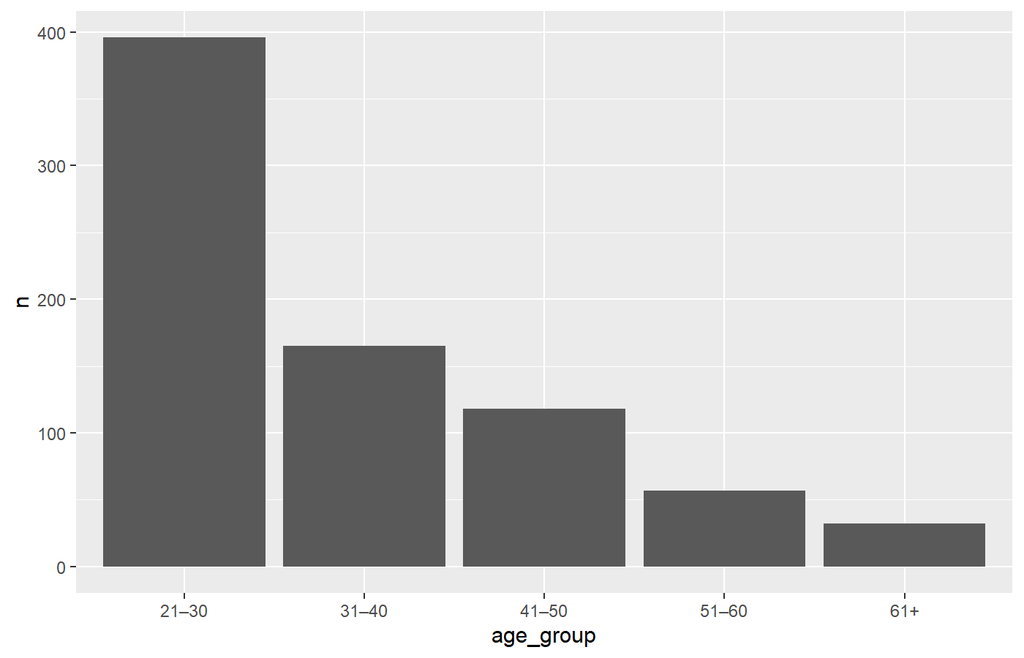

```r
ggplot(age_counts, aes(x = age_group, y = n)) +
  geom_col()
```

### Apply the three rules

**Rule 1 — y starts at zero (already does for `geom_col`, but be explicit):**

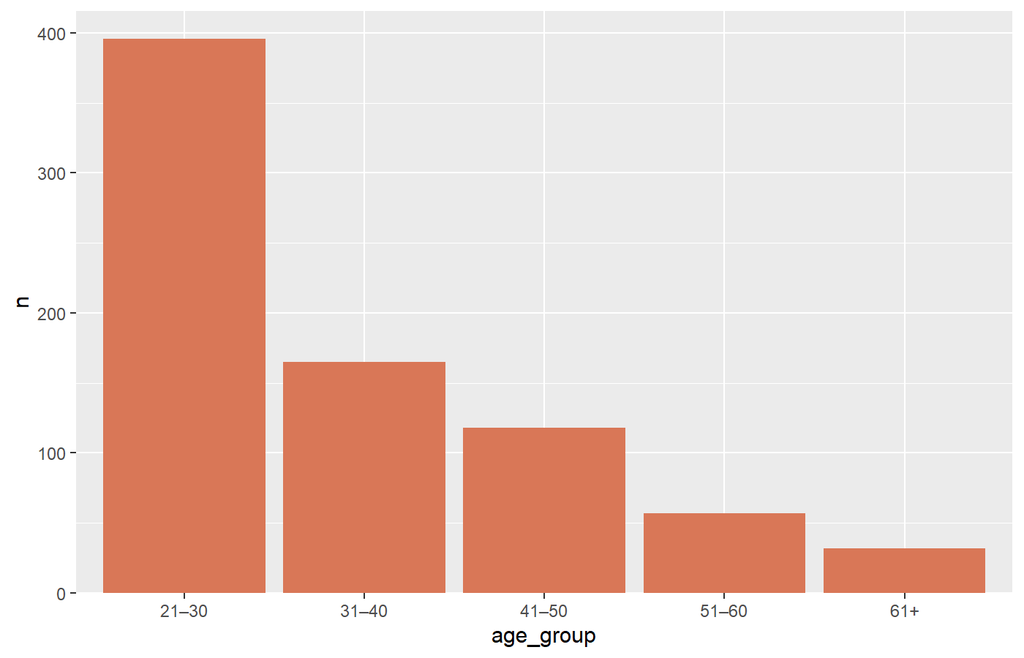

```r
ggplot(age_counts, aes(x = age_group, y = n)) +
  geom_col(fill = "#d97757") +
  scale_y_continuous(expand = expansion(mult = c(0, .05)))
```

**Rule 2 — sort by value with `fct_reorder`:**

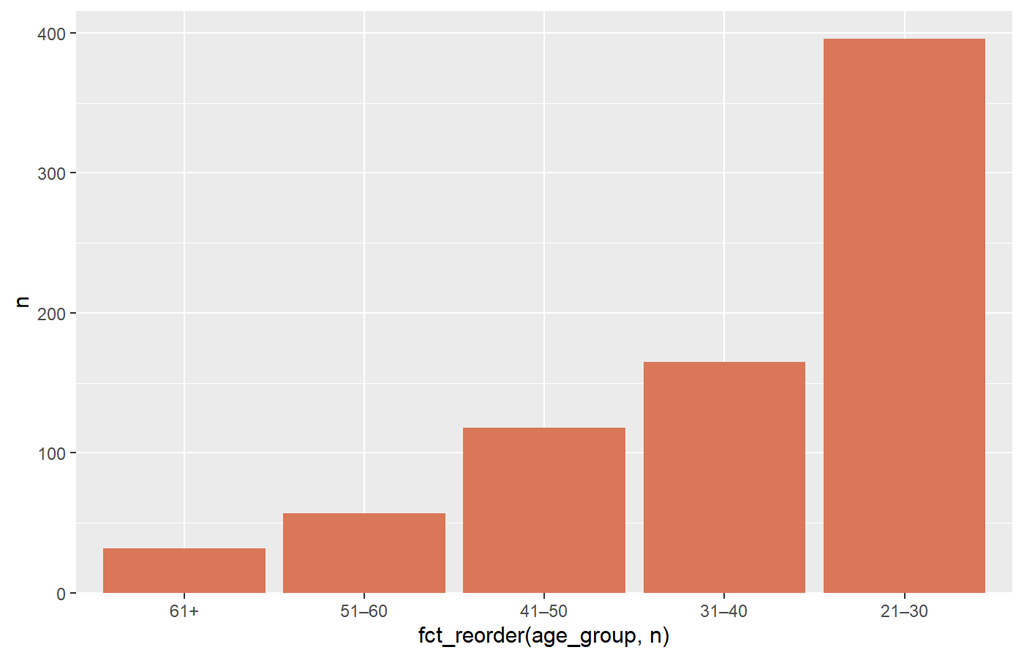

```r
ggplot(age_counts, aes(x = fct_reorder(age_group, n), y = n)) +
  geom_col(fill = "#d97757") +
  scale_y_continuous(expand = expansion(mult = c(0, .05)))
```

> **When NOT to sort:** ordinal categories like age groups have a natural order. For a real ordered category we’d skip `fct_reorder`. Switch to a different example to see sorting earn its keep:

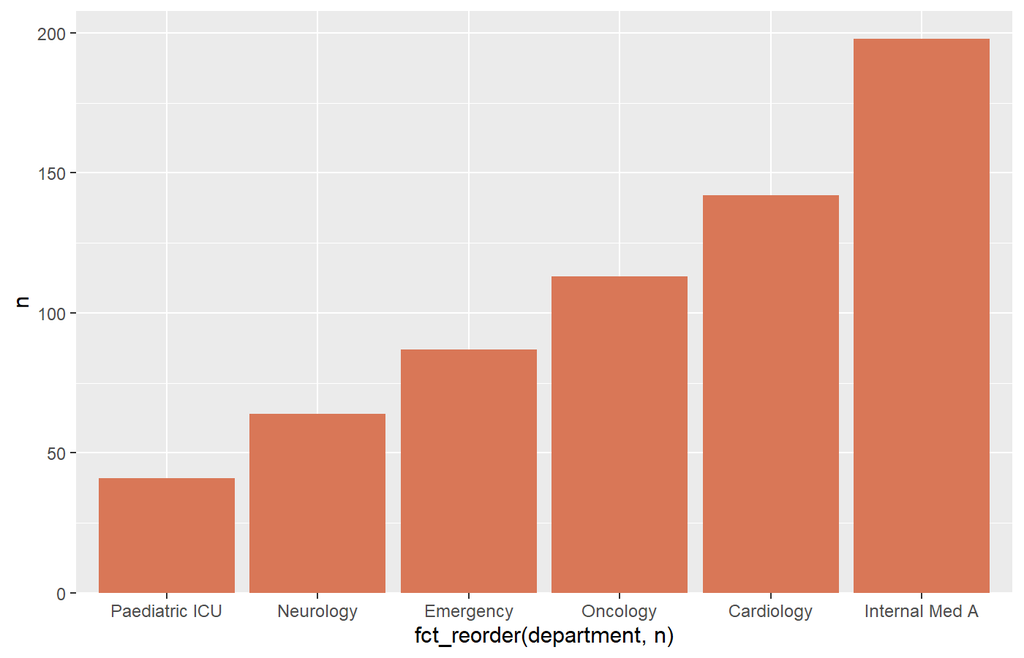

```r
# Imagine departments instead of ages — no inherent order
dept <- tibble(
  department = c("Cardiology", "Internal Med A", "Emergency",
                 "Neurology", "Paediatric ICU", "Oncology"),
  n = c(142, 198, 87, 64, 41, 113)
)

ggplot(dept, aes(x = fct_reorder(department, n), y = n)) +
  geom_col(fill = "#d97757") +
  scale_y_continuous(expand = expansion(mult = c(0, .05)))
```

**Rule 3 — long labels? `coord_flip()`:**

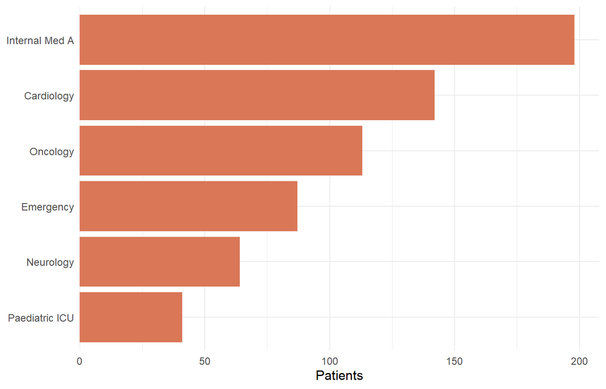

```r
ggplot(dept, aes(x = fct_reorder(department, n), y = n)) +
  geom_col(fill = "#d97757") +
  coord_flip() +
  scale_y_continuous(expand = expansion(mult = c(0, .05))) +
  labs(x = NULL, y = "Patients") +
  theme_minimal()
```

## 2. Histogram — distribution shape

### Default — what does ggplot2 give us?

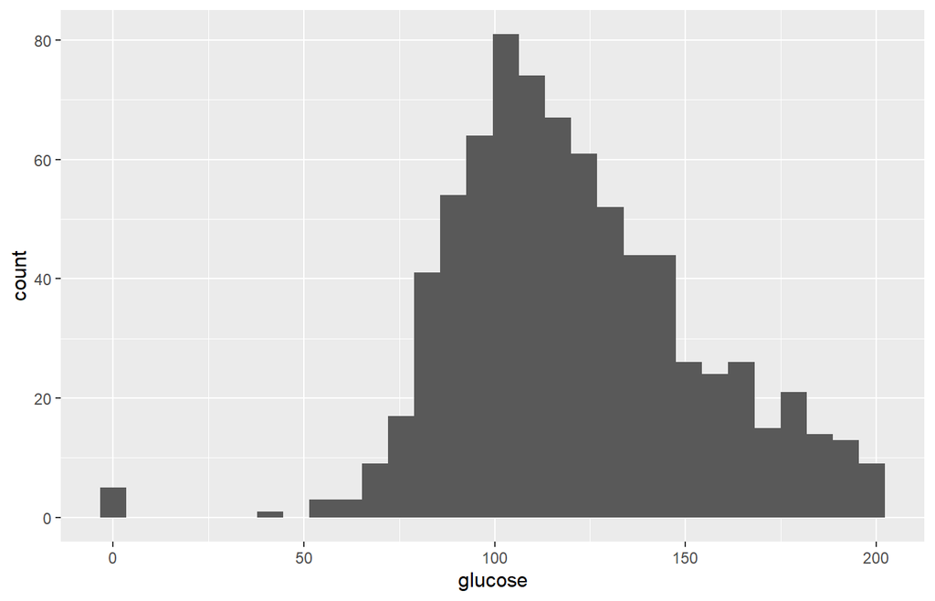

```r
ggplot(pima, aes(x = glucose)) +
  geom_histogram()
```

ggplot warns: *“stat_bin() using `bins = 30`. Pick better value with `binwidth`.”* It’s right. 30 is arbitrary.

### Filter the zeros

Glucose = 0 is impossible — those are missing values coded as zero. Same for `mass`, `pressure`, `triceps`, `insulin`. Always check.

```r
pima_clean <- pima |>
  filter(glucose > 0, mass > 0, pressure > 0)

nrow(pima)         # before
```

```
## [1] 768
```

```r
nrow(pima_clean)   # after
```

```
## [1] 724
```

### Bin width matters

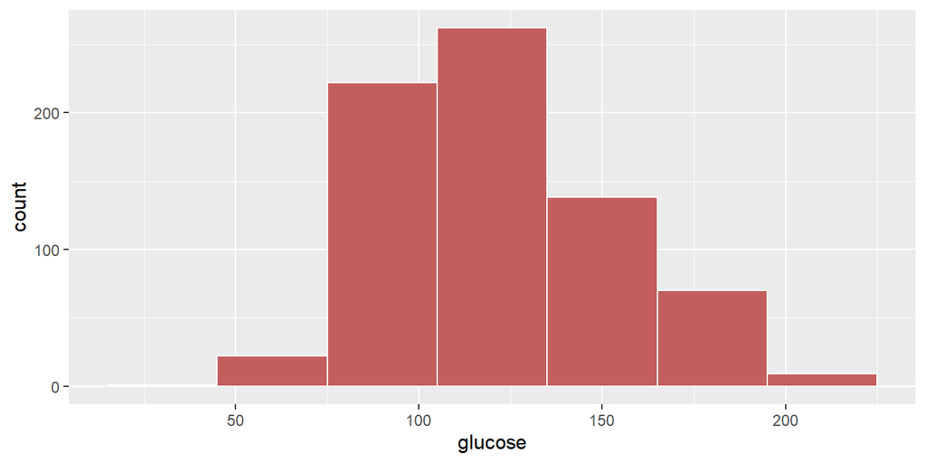

```r
ggplot(pima_clean, aes(x = glucose)) +
  geom_histogram(binwidth = 30, fill = "#c45e5e", color = "white")
```

Too coarse — the structure is hidden.

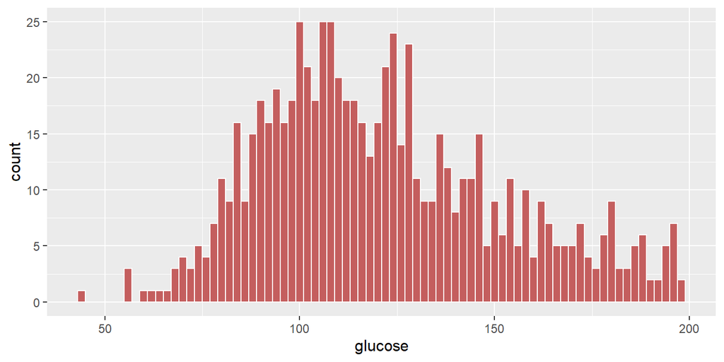

```r
ggplot(pima_clean, aes(x = glucose)) +
  geom_histogram(binwidth = 2, fill = "#c45e5e", color = "white")
```

Too fine — pure noise.

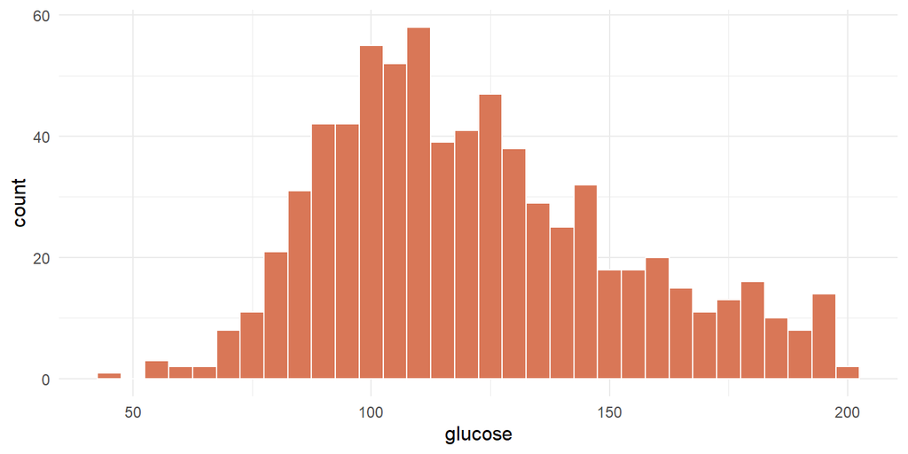

```r
ggplot(pima_clean, aes(x = glucose)) +
  geom_histogram(binwidth = 5, fill = "#d97757", color = "white") +
  theme_minimal()
```

### Why `color = "white"` matters

The white outline acts as a separator between bins. It costs no data ink but gains huge readability.

## 3. Box plot — beyond the average

### Single boxplot

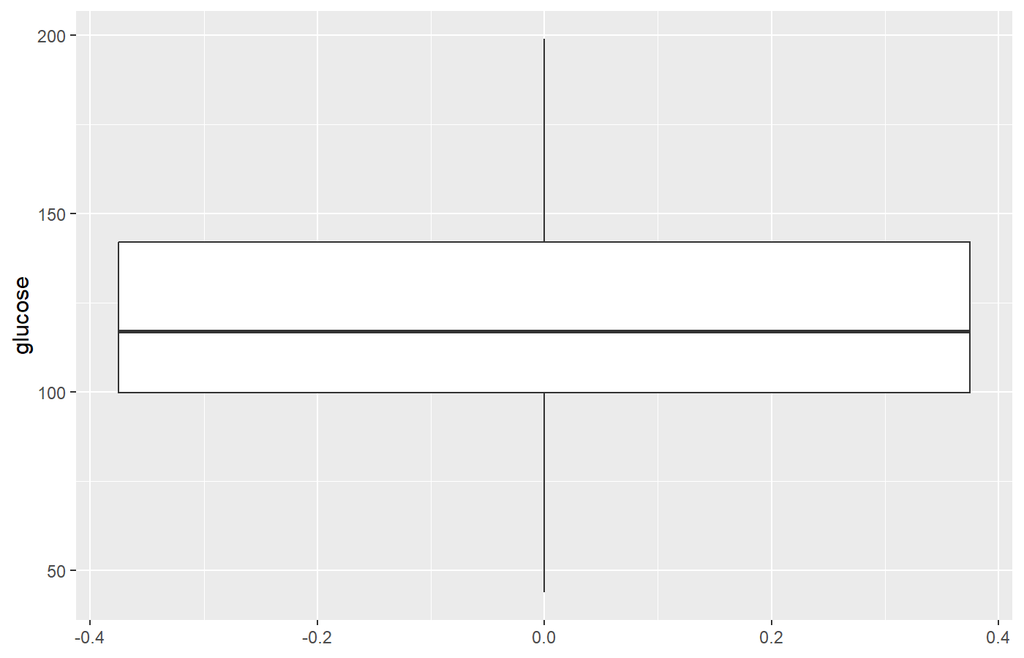

```r
ggplot(pima_clean, aes(y = glucose)) +
  geom_boxplot()
```

That’s the five-number summary in one shape: min, Q1, median, Q3, max, plus outliers as dots.

### Compared across groups — this is where boxplots earn their keep

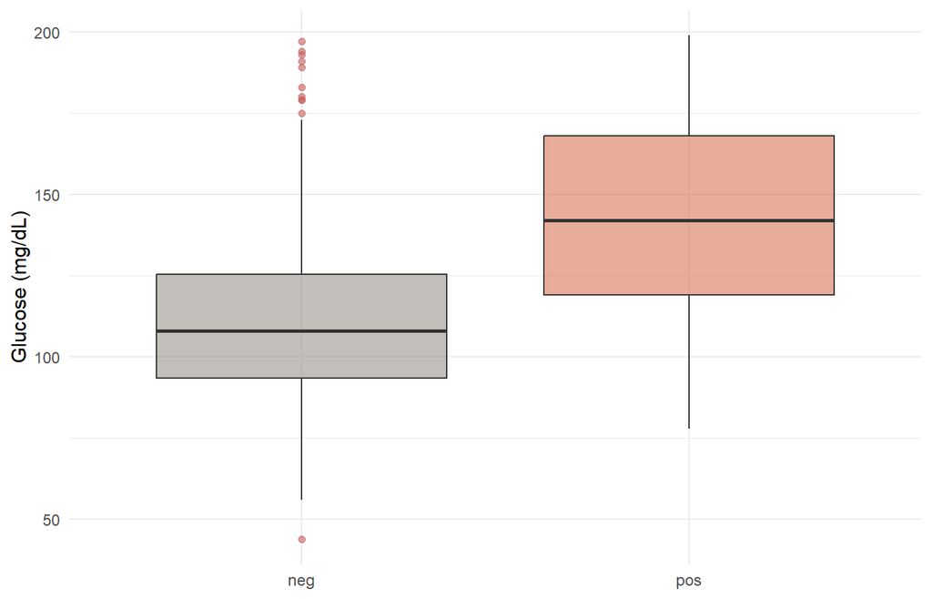

```r
ggplot(pima_clean, aes(x = diabetes, y = glucose, fill = diabetes)) +
  geom_boxplot(alpha = 0.6, outlier.color = "#c45e5e") +
  scale_fill_manual(values = c("neg" = "#9a958c", "pos" = "#d97757")) +
  theme_minimal() +
  labs(x = NULL, y = "Glucose (mg/dL)") +
  theme(legend.position = "none")
```

Diabetic patients have higher glucose. The medians don’t even overlap with the boxes of the other group — that’s a strong visual signal.

### Upgrade 1: when there are few points, add `geom_jitter`

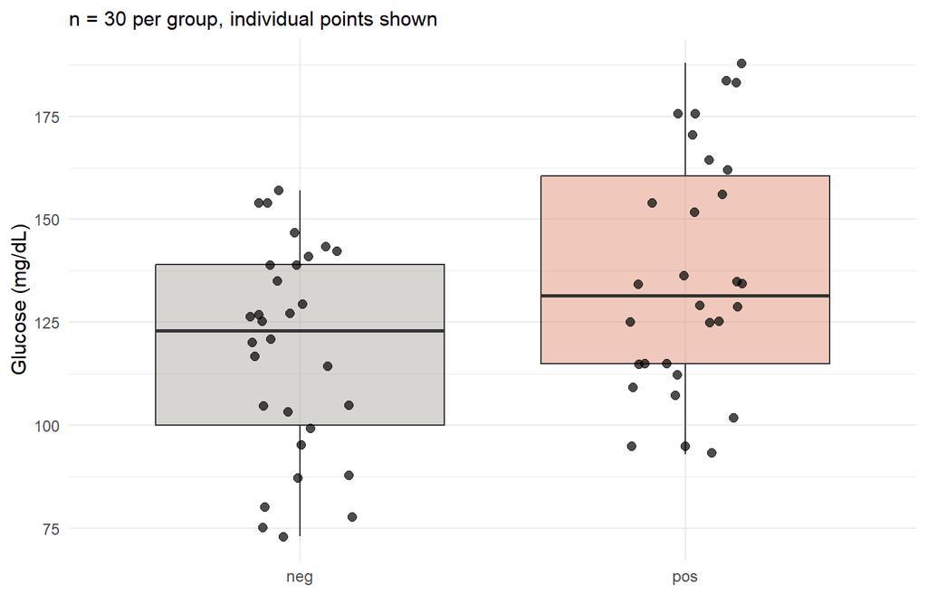

```r
pima_small <- pima_clean |>
  group_by(diabetes) |>
  slice_sample(n = 30) |>
  ungroup()

ggplot(pima_small, aes(x = diabetes, y = glucose, fill = diabetes)) +
  geom_boxplot(alpha = 0.4, outlier.shape = NA) +
  geom_jitter(width = 0.15, alpha = 0.7, size = 2) +
  scale_fill_manual(values = c("neg" = "#9a958c", "pos" = "#d97757")) +
  theme_minimal() +
  theme(legend.position = "none") +
  labs(x = NULL, y = "Glucose (mg/dL)",
       subtitle = "n = 30 per group, individual points shown")
```

### Upgrade 2: when there are many points, switch to violin

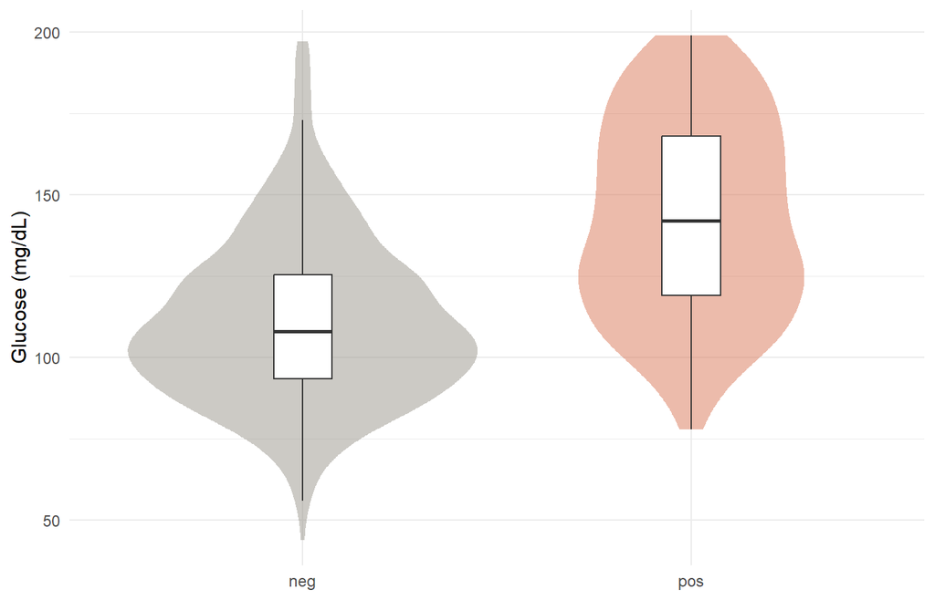

```r
ggplot(pima_clean, aes(x = diabetes, y = glucose, fill = diabetes)) +
  geom_violin(alpha = 0.5, color = NA) +
  geom_boxplot(width = 0.15, fill = "white", outlier.shape = NA) +
  scale_fill_manual(values = c("neg" = "#9a958c", "pos" = "#d97757")) +
  theme_minimal() +
  theme(legend.position = "none") +
  labs(x = NULL, y = "Glucose (mg/dL)")
```

The violin reveals what the box hides — the shape of the distribution inside the IQR. Notice the diabetic group’s density is bimodal-ish; the boxplot alone would never show that.